# Types of Major Weather Events and Storms, 1950-2011

The following analysis was conducted with data from the U.S. National Oceanic and Atmospheric Administration’s (NOAA) storm database. The analysis is a systematic exploration of major storm and weather events, recorded between 1950 and the later part of 2011.

From this exploration, the analysis attempts to answer two questions:

1. Across the United States, which types of weather or storm events were most harmful in respect to population health;
2. and, which types of events had the greatest economic consequences.

In the Data Processing section of this analysis, a thorough description of how the data was loaded and processed is provided, from how the raw .csv file was loaded for analysis with R, to any transformations undertaken to prepare the data for the analysis phase. Included is how the compressed file containing the data was downloaded and then extracted to a .csv form.

## Data Processing

```r
options(scipen = 1, digits = 2)

# Download .bz2 compressed file to current working directory
download.file("https://d396qusza40orc.cloudfront.net/repdata%2Fdata%2FStormData.csv.bz2","stormy.bz2")

# Read .csv file
sd<-read.csv("stormy.bz2")
```

### Question: Across the United States, which types of events (as indicated in the EVTYPE variable) are most harmful with respect to population health?

We’ll begin by understanding the structure of the data, here referenced as data frame sd.

Of the over 30 variables, the analysis is only concerned with a handful:

```r
# Review structure
str(sd)
```

```
## 'data.frame':    902297 obs. of  37 variables:
##  $ STATE__   : num  1 1 1 1 1 1 1 1 1 1 ...
##  $ BGN_DATE  : Factor w/ 16335 levels "1/1/1966 0:00:00",..: 6523 6523 4242 11116 2224 2224 2260 383 3980 3980 ...
##  $ BGN_TIME  : Factor w/ 3608 levels "00:00:00 AM",..: 272 287 2705 1683 2584 3186 242 1683 3186 3186 ...
##  $ TIME_ZONE : Factor w/ 22 levels "ADT","AKS","AST",..: 7 7 7 7 7 7 7 7 7 7 ...
##  $ COUNTY    : num  97 3 57 89 43 77 9 123 125 57 ...
##  $ COUNTYNAME: Factor w/ 29601 levels "","5NM E OF MACKINAC BRIDGE TO PRESQUE ISLE LT MI",..: 13513 1873 4598 10592 4372 10094 1973 23873 24418 4598 ...
##  $ STATE     : Factor w/ 72 levels "AK","AL","AM",..: 2 2 2 2 2 2 2 2 2 2 ...
##  $ EVTYPE    : Factor w/ 985 levels "   HIGH SURF ADVISORY",..: 834 834 834 834 834 834 834 834 834 834 ...
##  $ BGN_RANGE : num  0 0 0 0 0 0 0 0 0 0 ...
##  $ BGN_AZI   : Factor w/ 35 levels "","  N"," NW",..: 1 1 1 1 1 1 1 1 1 1 ...
##  $ BGN_LOCATI: Factor w/ 54429 levels ""," Christiansburg",..: 1 1 1 1 1 1 1 1 1 1 ...
##  $ END_DATE  : Factor w/ 6663 levels "","1/1/1993 0:00:00",..: 1 1 1 1 1 1 1 1 1 1 ...
##  $ END_TIME  : Factor w/ 3647 levels ""," 0900CST",..: 1 1 1 1 1 1 1 1 1 1 ...
##  $ COUNTY_END: num  0 0 0 0 0 0 0 0 0 0 ...
```

[output cut: 23 more lines]

The structure function reveals two numeric vectors, FATALITIES and INJURIES. Assuming these are the number of occurrences of each for each EVTYPE-weather or storm event, we’ll sum each vector and group them by EVTYPE, in pd.

```r
pd<-aggregate(list(FATALITIES=sd$FATALITIES,INJURIES=sd$INJURIES),list(EVTYPE=sd$EVTYPE),sum)
```

The final step is to sum the two numreric vectors together and put their total in a new vector, HARM, and plot the events that are most harmful to population health. The analysis considers population health as any value of HARM greater than 1 for a given event type.

```r
pd$HARM<-pd$FATALITIES + pd$INJURIES
```

For purpose of analysis, we further limit the observations of pd to the top 20 events types by HARM value, in plotme.

```r
plotme<-pd[order(pd$HARM,decreasing = TRUE),]
plotme<-plotme[1:20,]

plotme[order(plotme$HARM,decreasing = TRUE),]
```

```
##                 EVTYPE FATALITIES INJURIES  HARM
## 834            TORNADO       5633    91346 96979
## 130     EXCESSIVE HEAT       1903     6525  8428
## 856          TSTM WIND        504     6957  7461
## 170              FLOOD        470     6789  7259
## 464          LIGHTNING        816     5230  6046
## 275               HEAT        937     2100  3037
## 153        FLASH FLOOD        978     1777  2755
## 427          ICE STORM         89     1975  2064
## 760  THUNDERSTORM WIND        133     1488  1621
## 972       WINTER STORM        206     1321  1527
## 359          HIGH WIND        248     1137  1385
## 244               HAIL         15     1361  1376
## 411  HURRICANE/TYPHOON         64     1275  1339
## 310         HEAVY SNOW        127     1021  1148
## 957           WILDFIRE         75      911   986
## 786 THUNDERSTORM WINDS         64      908   972
## 30            BLIZZARD        101      805   906
## 188                FOG         62      734   796
## 585        RIP CURRENT        368      232   600
## 955   WILD/FOREST FIRE         12      545   557
```

### Question: Across the United States, which types of events had the greatest economic consequences?

The second question is similar to the first, in that we can use the same process and even some of the same variables to prepare the data for plotting.

Here, we will use the following variables, some we’ve seen before:  
1. EVTYPE  
2. PROPDMG  
3. CROPDMG

(We make the assumption that CROPDMG is not a constituent of PROPDMG.)  
Similar to the first question, here we sum up two numeric vectors by event type. The data frame is referenced as db.

```r
# Create the dataset that sums PROPDMG and CROPDMG by EVTYPE
db<-aggregate(list(PROPDMG=sd$PROPDMG,CROPDMG=sd$CROPDMG),list(EVTYPE=sd$EVTYPE),sum)
```

We then add the PROPDMG variable to the CROPDMG variable into a new vector, TOTDMG.

```r
db$TOTDMG<-db$PROPDMG + db$CROPDMG

str(db)
```

```
## 'data.frame':    985 obs. of  4 variables:
##  $ EVTYPE : Factor w/ 985 levels "   HIGH SURF ADVISORY",..: 1 2 3 4 5 6 7 8 9 10 ...
##  $ PROPDMG: num  200 0 50 0 108 8 0 0 5 0 ...
##  $ CROPDMG: num  0 0 0 0 0 0 0 0 0 0 ...
##  $ TOTDMG : num  200 0 50 0 108 8 0 0 5 0 ...
```

For this second plot, we are interested only in the top 20 event types calculated by TOTDMG size.

```r
#Subset to top 20 largest damages
dmplot<-db[order(db$TOTDMG,decreasing = TRUE),]
dmplot<-dmplot[1:20,]

dmplot[order(dmplot$TOTDMG, decreasing = TRUE),]
```

```
##                 EVTYPE PROPDMG CROPDMG  TOTDMG
## 834            TORNADO 3212258  100019 3312277
## 153        FLASH FLOOD 1420125  179200 1599325
## 856          TSTM WIND 1335966  109203 1445168
## 244               HAIL  688693  579596 1268290
## 170              FLOOD  899938  168038 1067976
## 760  THUNDERSTORM WIND  876844   66791  943636
## 464          LIGHTNING  603352    3581  606932
## 786 THUNDERSTORM WINDS  446293   18685  464978
## 359          HIGH WIND  324732   17283  342015
## 972       WINTER STORM  132721    1979  134700
## 310         HEAVY SNOW  122252    2166  124418
## 957           WILDFIRE   84459    4364   88824
## 427          ICE STORM   66001    1689   67690
## 676        STRONG WIND   62994    1617   64611
## 290         HEAVY RAIN   50842   11123   61965
## 376         HIGH WINDS   55625    1760   57385
## 848     TROPICAL STORM   48424    5899   54323
## 955   WILD/FOREST FIRE   39345    4190   43534
## 95             DROUGHT    4099   33899   37998
## 164     FLASH FLOODING   28497    5126   33623
```

## Results

We can now plot the the data for both questions and hopefully provide insight into the types of weather and storm events that are of concern in terms of population health and economic consequences:

1. Across the United States, which types of weather or storm events were most harmful in respect to population health?

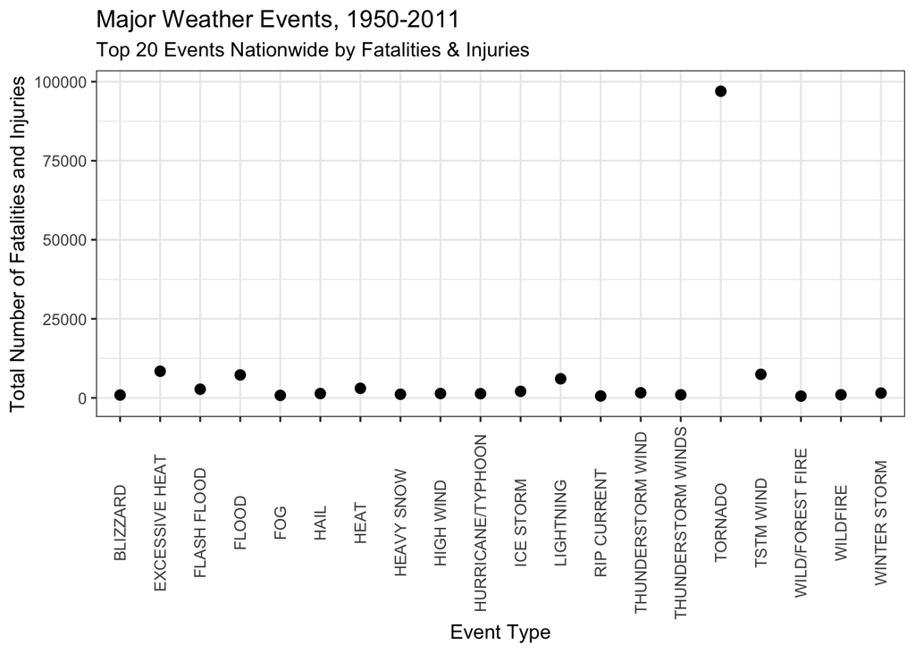

```r
library(ggplot2)
theme_set(theme_bw())

# Draw plot

ggplot(plotme, aes(x = factor(EVTYPE), y = HARM)) +
  geom_dotplot(binaxis = "y",
               stackdir = "center")+
  theme(axis.text.x = element_text(angle=90, vjust = 0.5)) +
  labs(title="Major Weather Events, 1950-2011",
       subtitle="Top 20 Events Nationwide by Fatalities & Injuries",
       x="Event Type",
       y="Total Number of Fatalities and Injuries")
```

2. Across the United States, which types of events had the greatest economic consequences?

```r
require(scales)
```

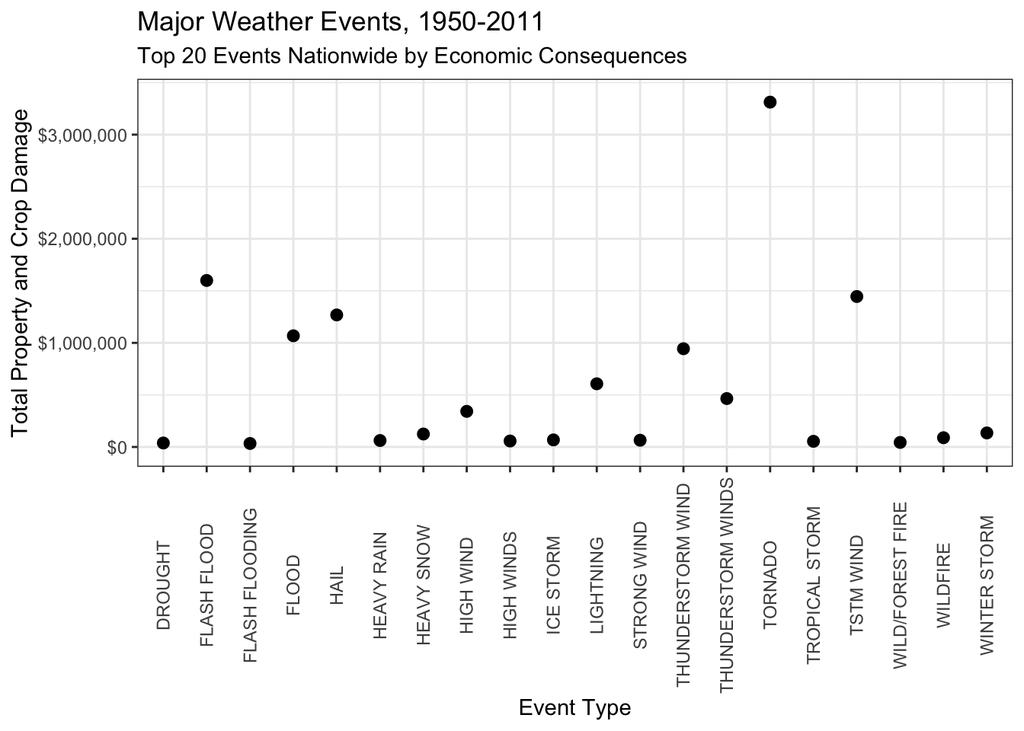

```r
# Draw plot
ggplot(dmplot, aes(x = factor(EVTYPE), y = TOTDMG)) +
  geom_dotplot(binaxis = "y",
               stackdir = "center")+
  theme(axis.text.x = element_text(angle=90, vjust = 0.5)) +
  labs(title="Major Weather Events, 1950-2011",
       subtitle="Top 20 Events Nationwide by Economic Consequences",
       x="Event Type",
       y="Total Property and Crop Damage") +
       scale_y_continuous(labels=dollar_format(prefix="$"))
```